# 01 - Calculate EpiDISH and clocks

In this script, the DNA-methylation data will be loaded and used to predict the following:

1. Blood cell counts, predicted by [EpiDISH](https://genomemedicine.biomedcentral.com/articles/10.1186/s13073-023-01211-5), of 12 cell fractions: neutrophils, eosinophils, basophils, monocytes, naive B cells, memory B cells, naive CD4 T cells, memory CD4 T cells, naive CD8 T cells, memory CD8 T cells, regulatory T cells, and natural killer cells.
2. Six epigenetic clocks, including three 1st-generation clocks ([Hannum](https://pmc.ncbi.nlm.nih.gov/articles/PMC3780611/), [Horvath](https://pmc.ncbi.nlm.nih.gov/articles/PMC4015143/), and [Zhang](https://genomemedicine.biomedcentral.com/articles/10.1186/s13073-019-0667-1)), and three 2nd-generation clocks ([PhenoAge](https://pmc.ncbi.nlm.nih.gov/articles/PMC5940111/), [GrimAge](https://pmc.ncbi.nlm.nih.gov/articles/PMC6366976/), and [DunedinPACE](https://elifesciences.org/articles/73420))

Additionally, correction for batch effects will be performed using ComBat, and the impact of this step will be visualized with some before-and-after plots.

# Load data

```r
setwd("/exports/molepi/RSC_BIOS/Users/tjonkman/cellcounts")
.libPaths("/exports/molepi/RSC_BIOS/Users/tjonkman/Packages/4.3.1")

library(SummarizedExperiment)
load("/exports/archive/molepi-lts/processing/RSC_BIOS/RP3_data/IlluminaHumanMethylation450k/450k/methData_Betas_BIOS_Freeze2_unrelated.RData")

#Remove samples with NAs in age, sex, or study.
betas <- betas[,!is.na(betas$sampling_age)]
betas <- betas[,!is.na(betas$sex)]
betas <- betas[,!is.na(betas$biobank_id)]
class(betas)
```

```
## [1] "RangedSummarizedExperiment"
## attr(,"package")
## [1] "SummarizedExperiment"
```

```r
dim(betas)
```

```
## [1] 481388   4121
```

# Correct for batch effects

*NB: this code will not be run inside R Markdown because it takes a very large amount of time and resources to run. Instead, it has been run inside RStudio, and its output will be loaded in in the next chunk.*

```r
#Check for batch effects in the DNAm-data before ComBat.
gc()
set.seed(1)
pca <- prcomp(t(assay(betas)), scale = TRUE)
gc()

pca.df <- as.data.frame(pca$x)
var.ex <- pca$sdev^2 / sum(pca$sdev^2)
library(ggplot2)
ggplot(pca.df, aes(x = PC1, y = PC2)) +
  geom_point(aes(color = betas$biobank_id)) +
  scale_color_manual(values = c("#E41A1C", "#377EB8", "#4DAF4A", "#984EA3", "#FF7F00", "#37B8B2", "#F781BF")) +
  labs(x = paste0("PC1: ", round(var.ex[1]*100, 1), "%"), y = paste0("PC2: ", round(var.ex[2]*100, 1), "%")) +
  ggtitle("") +
  theme_bw()

#Peform ComBat adjustment for batch effects.
library(sva)
mm = model.matrix(~sampling_age, data = colData(betas))
gc()
betas.combat <- ComBat(
  dat = assay(betas),
  batch = factor(betas$biobank_id),
  mod = mm,
  par.prior=T,
  )
betas.combat[betas.combat < 0] <- 0
betas.combat[betas.combat > 1] <- 1
length(which(betas.combat < 0))
length(which(betas.combat > 1))
gc()

#Check for batch effects in the DNAm-data after ComBat.
gc()
set.seed(1)
pca <- prcomp(t(betas.combat), scale = FALSE)
gc()

pca.df <- as.data.frame(pca$x)
var.ex <- pca$sdev^2 / sum(pca$sdev^2)
ggplot(pca.df, aes(x = PC1, y = PC2)) +
  geom_point(shape = 1, aes(color = betas$biobank_id)) +
  scale_color_manual(values = c("#E41A1C", "#377EB8", "#4DAF4A", "#984EA3", "#FF7F00", "#37B8B2", "#F781BF")) +
  labs(x = paste0("PC1: ", round(var.ex[1]*100, 1), "%"), y = paste0("PC2: ", round(var.ex[2]*100, 1), "%")) +
  ggtitle("") +
  theme_bw()

#Save the ComBat-corrected DNAm-values.
save(betas.combat, file = "01_betas_after_combat.rda")
```

# Predict cell counts

Predict cells counts using EpiDISH.

```r
load("01_betas_after_ComBat.rda")
assay(betas) <- betas.combat
rm(betas.combat)
gc()
```

```
##              used    (Mb) gc trigger    (Mb)   max used    (Mb)
## Ncells    7491941   400.2   11442818   611.2    7708918   411.8
## Vcells 2006958421 15311.9 5935207700 45282.1 4121190483 31442.2
```

```r
library(EpiDISH)
ed <- epidish(beta.m = assay(betas), ref.m = cent12CT450k.m, method = "RPC")
cc <- ed$estF

cc <- cc[,c("Neu", "Eos", "Baso", "Mono", "Bnv", "Bmem", "CD4Tnv", "CD4Tmem", "CD8Tnv", "CD8Tmem", "Treg", "NK")]
cc <- cc*100
class(cc)
```

```
## [1] "matrix" "array"
```

```r
dim(cc)
```

```
## [1] 4121   12
```

```r
save(cc, file = "01_epiDISH.rda")
```

Cell counts were also calculated before batch correction using ComBat. Check the difference between the two.

```r
load("test/cc_before_combat.rda")
cc_before_combat <- cc_before_combat[rownames(cc),]
class(cc_before_combat)
```

```
## [1] "matrix" "array"
```

```r
dim(cc_before_combat)
```

```
## [1] 4121   12
```

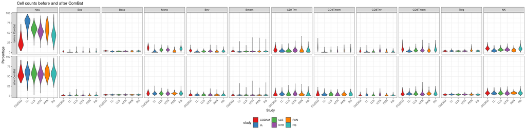

```r
#Prepare plot data.
plot.data <- as.data.frame(colData(betas)[, c("uuid", "sampling_age", "biobank_id")])

plot.data <- cbind(plot.data, cc_before_combat)
colnames(plot.data)[4:15] <- paste0(colnames(plot.data)[4:15], "-before ComBat")

plot.data <- cbind(plot.data, cc)
colnames(plot.data)[16:27] <- paste0(colnames(plot.data)[16:27], "-after ComBat")

library(reshape2)
plot.data <- melt(plot.data, id.vars = c("uuid", "sampling_age", "biobank_id"))
colnames(plot.data) <- c("id", "age", "study", "variable", "percentage")

x <- do.call("rbind", strsplit(x = as.character(plot.data$variable), split = "-"))
plot.data$cell.type <- factor(x[,1], levels = colnames(cc))
plot.data$combat <- factor(x[,2], levels = c("before ComBat", "after ComBat"))

#Violin plots of the distribution of each cell type per cohort.
library(ggplot2)
ggplot(plot.data, aes(x = study, y = percentage, fill = study)) +
  geom_violin(color = "#444444") +
  facet_grid(rows = vars(combat), cols = vars(cell.type), scales = "free", switch = "y") +
  scale_fill_manual(values = c("#E41A1C", "#377EB8", "#4DAF4A", "#984EA3", "#FF7F00", "#37B8B2", "#F781BF")) +
  theme_bw() +
  theme(
    legend.position = "bottom",
    axis.text.x = element_text(angle = 45, hjust = 1)
    ) +
  labs(x = "Study", y = "Percentage", title = "Cell counts before and after ComBat")
```

# Calculate clocks

Split betas into 9 chunks (clocks calculation crashes if too many samples are included).

```r
#Split the data into 5 chunks.
betas.1 <- betas[, 1:500]
betas.2 <- betas[, 501:1000]
betas.3 <- betas[, 1001:1500]
betas.4 <- betas[, 1501:2000]
betas.5 <- betas[, 2001:2500]
betas.6 <- betas[, 2501:3000]
betas.7 <- betas[, 3001:3500]
betas.8 <- betas[, 3501:4000]
betas.9 <- betas[, 4001:4121]

save(betas.1, file = "test/betas.1.rda")
save(betas.2, file = "test/betas.2.rda")
save(betas.3, file = "test/betas.3.rda")
save(betas.4, file = "test/betas.4.rda")
save(betas.5, file = "test/betas.5.rda")
save(betas.6, file = "test/betas.6.rda")
save(betas.7, file = "test/betas.7.rda")
save(betas.8, file = "test/betas.8.rda")
save(betas.9, file = "test/betas.9.rda")

ss <- as.data.frame(colData(betas))

ss$sex <- as.factor(ss$sex)
ss$biobank_id <- as.factor(ss$biobank_id)

#Add some columns to accomodate the PC-GrimAge clock.
ss$Age <- ss$sampling_age
ss$Female <- as.character(ss$sex)
ss$Female[ss$Female == "male"] <- 0
ss$Female[ss$Female == "female"] <- 1
ss$Female <- as.numeric(ss$Female)
class(ss)
```

```
## [1] "data.frame"
```

```r
dim(ss)
```

```
## [1] 4121   84
```

```r
save(ss, file = "01_clock_sample_sheet.rda")

rm(betas, betas.1, betas.2, betas.3, betas.4, betas.5, betas.6, betas.7, betas.8, betas.9)
gc()
```

```
##            used  (Mb) gc trigger    (Mb)   max used    (Mb)
## Ncells  5895200 314.9   11442818   611.2   11442818   611.2
## Vcells 16103048 122.9 4748166160 36225.7 4121190483 31442.2
```

Calculate clocks for each chunk.

*NB: due to an error in R Markdown, the calcPCClocks function crashes when knitting the document. It does run normally when running the code normally from within R. As a workaround, this chunk has been run in RStudio, is being skipped in the knitting process (eval = F), and its output will be loaded in the next chunk*

```r
library(methylclock)
library(DunedinPACE)

#Set the directory for calculating the PC-GrimAge clock, and load the functions.
clocksDir <- "/exports/molepi/RSC_BIOS/Users/tjonkman/cellcounts/PC-clocks/"
source(paste(clocksDir, "run_calcPCClocks.R", sep = ""))
source(paste(clocksDir, "run_calcPCClocks_Accel.R", sep = ""))

#Define function to calculate the clocks of interest.
CalculateClocks <- function(betas){

  #Calculate most clocks using the methylclock package.
  clocks <- as.data.frame(DNAmAge(assay(betas)))

  #Calculate the PC GrimAge using the code from GitHub (https://github.com/MorganLevineLab/PC-Clocks)
  ss.subset <- ss[colnames(betas),]
  PCClock_DNAmAge <- calcPCClocks(path_to_PCClocks_directory = clocksDir,
                                     datMeth = t(assay(betas)),
                                     datPheno = ss.subset)
  clocks$GrimAge <- PCClock_DNAmAge$PCGrimAge


  #Calculate DunedinPACE.
  poa <- PACEProjector(assay(betas))
  clocks$DunedinPACE <- poa$DunedinPACE

  return(clocks)
}

#Calculate clocks for each chunk.
load("test/betas.1.rda")
clocks.1 <- CalculateClocks(betas.1)
skip
rm(betas.1)

load("test/betas.2.rda")
clocks.2 <- CalculateClocks(betas.2)
skip
rm(betas.2)

load("test/betas.3.rda")
clocks.3 <- CalculateClocks(betas.3)
skip
rm(betas.3)

load("test/betas.4.rda")
clocks.4 <- CalculateClocks(betas.4)
skip
rm(betas.4)

load("test/betas.5.rda")
clocks.5 <- CalculateClocks(betas.5)
skip
rm(betas.5)

load("test/betas.6.rda")
clocks.6 <- CalculateClocks(betas.6)
skip
rm(betas.6)

load("test/betas.7.rda")
clocks.7 <- CalculateClocks(betas.7)
skip
rm(betas.7)

load("test/betas.8.rda")
clocks.8 <- CalculateClocks(betas.8)
skip
rm(betas.8)

load("test/betas.9.rda")
clocks.9 <- CalculateClocks(betas.9)
skip
rm(betas.9)

#Bind the chunks together.
clocks <- rbind(clocks.1, clocks.2, clocks.3, clocks.4, clocks.5, clocks.6, clocks.7, clocks.8, clocks.9)
class(clocks)
dim(clocks)
colnames(clocks)

save(clocks, file = "01_clocks.rda")
```

Just like the cell counts, the clocks were also calculated before ComBat. Compare the results.

```r
load("01_clocks.rda")
load("test/clocks_before_combat.rda")
load("01_clock_sample_sheet.rda")
clocks_before_combat <- clocks_before_combat[rownames(clocks),]
class(clocks_before_combat)
```

```
## [1] "data.frame"
```

```r
dim(clocks_before_combat)
```

```
## [1] 4121   13
```

```r
colnames(clocks_before_combat)
```

```
##  [1] "id"          "Horvath"     "Hannum"      "Levine"      "BNN"
##  [6] "skinHorvath" "PedBE"       "Wu"          "TL"          "BLUP"
## [11] "EN"          "GrimAge"     "DunedinPACE"
```

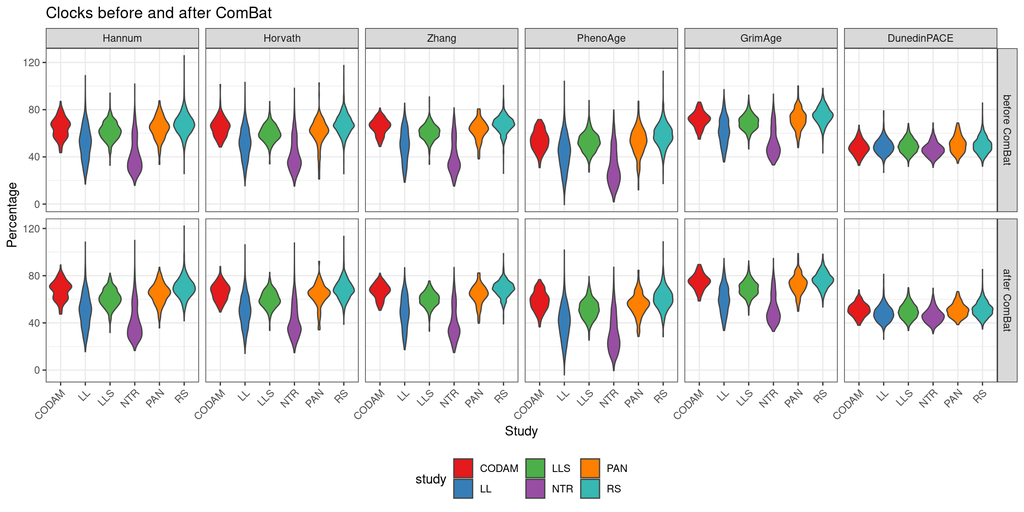

```r
#Prepare plot data.
plot.data <- as.data.frame(ss[, c("uuid", "sampling_age", "biobank_id")])

plot.data <- cbind(plot.data, clocks_before_combat[,c(3, 2, 11, 4, 12, 13)])
colnames(plot.data)[4:9] <- c("Hannum", "Horvath", "Zhang", "PhenoAge", "GrimAge", "DunedinPACE")
colnames(plot.data)[4:9] <- paste0(colnames(plot.data)[4:9], "-before ComBat")

plot.data <- cbind(plot.data, clocks[,c(3, 2, 11, 4, 12, 13)])
colnames(plot.data)[10:15] <- c("Hannum", "Horvath", "Zhang", "PhenoAge", "GrimAge", "DunedinPACE")
colnames(plot.data)[10:15] <- paste0(colnames(plot.data)[10:15], "-after ComBat")

#Transform DunedinPACE into weeks instead of years.
plot.data[,grep(pattern = "DunedinPACE", x = colnames(plot.data))] <- (plot.data[,grep(pattern = "DunedinPACE", x = colnames(plot.data))] * 52.143)
plot.data <- melt(plot.data, id.vars = c("uuid", "sampling_age", "biobank_id"))
colnames(plot.data) <- c("id", "age", "study", "variable", "DNAmAge")

x <- do.call("rbind", strsplit(x = as.character(plot.data$variable), split = "-"))
plot.data$cell.type <- factor(x[,1], levels = c("Hannum", "Horvath", "Zhang", "PhenoAge", "GrimAge", "DunedinPACE"))
plot.data$combat <- factor(x[,2], levels = c("before ComBat", "after ComBat"))

#Violin plots of the distribution of each cell type per cohort.
ggplot(plot.data, aes(x = study, y = DNAmAge, fill = study)) +
  geom_violin(color = "#444444") +
  facet_grid(rows = vars(combat), cols = vars(cell.type), scales = "free") +
  scale_fill_manual(values = c("#E41A1C", "#377EB8", "#4DAF4A", "#984EA3", "#FF7F00", "#37B8B2", "#F781BF")) +
  theme_bw() +
  theme(
    legend.position = "bottom",
    axis.text.x = element_text(angle = 45, hjust = 1)
    ) +
  labs(x = "Study", y = "Percentage", title = "Clocks before and after ComBat")
```

Combine all the information in a single sample sheet.

```r
#Check if the clocks match the cell counts and the sample sheet.
rownames(clocks) <- clocks$id
table(rownames(clocks) == rownames(cc)) #Should be 100% TRUE.
```

```
##
## TRUE
## 4121
```

```r
table(rownames(clocks) == rownames(ss)) #Should be 100% TRUE.
```

```
##
## TRUE
## 4121
```

```r
#Add age to the clock data.
clocks$age <- ss$sampling_age
clocks$sex <- ss$sex
clocks$study <- ss$biobank_id

#Initialize finalized sample sheet with a couple of columns from the clocks object.
ss <- data.frame(
  row.names = clocks$id,
  id = clocks$id,
  age = clocks$age,
  sex = clocks$sex,
  study = clocks$study,
  hannum = clocks$Hannum,
  horvath = clocks$Horvath,
  zhang = clocks$EN,
  phenoage = clocks$Levine,
  grimage = clocks$GrimAge,
  dunedinpace = clocks$DunedinPACE
)

#Add the cell counts.
ss <- cbind(ss, cc)

#Remove entries with NAs.
library(dplyr)
idx <- apply(ss, 1, anyNA)
ss[idx,]
```

```
##  [1] id          age         sex         study       hannum      horvath
##  [7] zhang       phenoage    grimage     dunedinpace Neu         Eos
## [13] Baso        Mono        Bnv         Bmem        CD4Tnv      CD4Tmem
## [19] CD8Tnv      CD8Tmem     Treg        NK
## <0 rows> (or 0-length row.names)
```

```r
ss <- ss[!idx,]

#Remove outliers for each cell type (5 SDs outside of the mean).
for(i in 11:22){
  ss <- ss[!(
  (ss[,i] > (mean(ss[,i]) + 5*sd(ss[,i]))) |
  (ss[,i] < (mean(ss[,i]) - 5*sd(ss[,i])))
    ),]
}

#Save a separate object containing only the cell counts.
cc <- ss[,11:22]

# Calculate clock residuals.
ss$hannumRes <- lm(formula = hannum ~ age, data = ss)$residuals
ss$horvathRes <- lm(formula = horvath ~ age, data = ss)$residuals
ss$zhangRes <- lm(formula = zhang ~ age, data = ss)$residuals
ss$phenoageRes <- lm(formula = phenoage ~ age, data = ss)$residuals
ss$grimageRes <- lm(formula = grimage ~ age, data = ss)$residuals

#Express dunedinPACE in weeks rather than years to make it easier to plot next to other clocks.
ss$dunedinpace <- ss$dunedinpace * 52.143

class(ss)
```

```
## [1] "data.frame"
```

```r
dim(ss)
```

```
## [1] 4058   27
```

```r
colnames(ss)
```

```
##  [1] "id"          "age"         "sex"         "study"       "hannum"
##  [6] "horvath"     "zhang"       "phenoage"    "grimage"     "dunedinpace"
## [11] "Neu"         "Eos"         "Baso"        "Mono"        "Bnv"
## [16] "Bmem"        "CD4Tnv"      "CD4Tmem"     "CD8Tnv"      "CD8Tmem"
## [21] "Treg"        "NK"          "hannumRes"   "horvathRes"  "zhangRes"
## [26] "phenoageRes" "grimageRes"
```

```r
save(ss, cc, file = "01_sample_sheet.rda")
```